# Laporan Minggu 1-2: Pengantar Pemrograman Data Spasial

Batas Administrasi Kabupaten/Kota Provinsi Jawa Timur

Nama - NPM

2026-10-15

## Deskripsi Singkat

Laporan ini mencakup pembelajaran dasar pemrograman R untuk data spasial: variabel, tipe data, struktur data, indexing, coercion, operator, dan visualisasi objek `sf`. Data yang digunakan adalah batas administrasi kabupaten/kota di Provinsi Jawa Timur.

## Modifikasi dari Kode Asli Dosen

Berikut perubahan yang dilakukan dari `Code_Week_1 and 2.R` versi dosen:

[output not shown]

## Data

```r
library(sf)
library(tidyverse)

jatim_path <- file.path("data", "Provinsi Jawa Timur-KAB_KOTA.geojson")
jatim <- st_read(jatim_path, quiet = TRUE)

glimpse(jatim)
```

```
## Rows: 38
## Columns: 8
## $ kode_kk   <chr> "35.28", "35.79", "35.16", "35.22", "35.27", "35.15", "35.06…
## $ kode_prov <chr> "35", "35", "35", "35", "35", "35", "35", "35", "35", "35", …
## $ kab_kota  <chr> "Pamekasan", "Kota Batu", "Mojokerto", "Bojonegoro", "Sampan…
## $ provinsi  <chr> "Jawa Timur", "Jawa Timur", "Jawa Timur", "Jawa Timur", "Jaw…
## $ fid       <chr> "35.28", "35.79", "35.16", "35.22", "35.27", "35.15", "35.06…
## $ nama      <chr> "Kabupaten Pamekasan", "Kota Batu", "Kabupaten Mojokerto", "…
## $ label     <chr> "Kabupaten Pamekasan, Provinsi Jawa Timur, 35.28", "Kota Bat…
## $ geometry  <MULTIPOLYGON [°]> MULTIPOLYGON Z (((113.4331 ..., MULTIPOLYGON Z …
```

```r
jatim %>%
  st_drop_geometry() %>%
  select(kab_kota, nama, kode_kk, provinsi)
```

```
##            kab_kota                  nama kode_kk   provinsi
## 1         Pamekasan   Kabupaten Pamekasan   35.28 Jawa Timur
## 2         Kota Batu             Kota Batu   35.79 Jawa Timur
## 3         Mojokerto   Kabupaten Mojokerto   35.16 Jawa Timur
## 4        Bojonegoro  Kabupaten Bojonegoro   35.22 Jawa Timur
## 5           Sampang     Kabupaten Sampang   35.27 Jawa Timur
## 6          Sidoarjo    Kabupaten Sidoarjo   35.15 Jawa Timur
## 7            Kediri      Kabupaten Kediri   35.06 Jawa Timur
## 8  Kota Probolinggo      Kota Probolinggo   35.74 Jawa Timur
## 9           Jombang     Kabupaten Jombang   35.17 Jawa Timur
## 10   Kota Mojokerto        Kota Mojokerto   35.76 Jawa Timur
## 11           Blitar      Kabupaten Blitar   35.05 Jawa Timur
## 12    Kota Pasuruan         Kota Pasuruan   35.75 Jawa Timur
## 13        Bondowoso   Kabupaten Bondowoso   35.11 Jawa Timur
## 14          Magetan     Kabupaten Magetan   35.20 Jawa Timur
```

[output cut: 24 more lines]

```r
cat("Jumlah kabupaten/kota:", nrow(jatim), "\n")
```

```
## Jumlah kabupaten/kota: 38
```

```r
cat("CRS:", st_crs(jatim)$epsg, "\n")
```

```
## CRS: 4326
```

```r
cat("Tipe geometri:", paste(unique(st_geometry_type(jatim)), collapse = ", "), "\n")
```

```
## Tipe geometri: MULTIPOLYGON
```

## Code dan Hasil

### 1. Variabel dan Assignment

```r
kab_kota <- "Surabaya"
kode_provinsi <- "35"
jumlah_kabkota <- 28L
luas_wilayah_km2 <- 47800.45
provinsi_pesisir <- TRUE

print(kab_kota)
```

```
## [1] "Surabaya"
```

```r
print(kode_provinsi)
```

```
## [1] "35"
```

```r
print(jumlah_kabkota)
```

```
## [1] 28
```

```r
print(luas_wilayah_km2)
```

```
## [1] 47800.45
```

```r
print(provinsi_pesisir)
```

```
## [1] TRUE
```

Modifikasi: semua variabel dummy diganti konteks Jawa Timur. `kode_provinsi = "35"` adalah kode BPS untuk Provinsi Jawa Timur.

### 2. Case Sensitivity

```r
Kab_Kota <- "Surabaya"
KAB_KOTA <- "SURABAYA"

print(c(kab_kota = kab_kota, Kab_Kota = Kab_Kota, KAB_KOTA = KAB_KOTA))
```

```
##   kab_kota   Kab_Kota   KAB_KOTA
## "Surabaya" "Surabaya" "SURABAYA"
```

Modifikasi: tidak ada perubahan logika, hanya nilai yang disesuaikan.

### 3. Tipe Data

```r
luas_kab_malang_km2 <- 3530.65
jumlah_kec_mojokerto <- 18L
status_kota <- "Kota"
kota_pesisir <- TRUE
nilai_kompleks <- 1 + 4i
data_hilang <- NA
objek_kosong <- NULL
bukan_angka <- NaN

atomic_objects <- list(
  luas_kab_malang_km2 = luas_kab_malang_km2,
  jumlah_kec_mojokerto = jumlah_kec_mojokerto,
  status_kota = status_kota,
  kota_pesisir = kota_pesisir,
  nilai_kompleks = nilai_kompleks,
  data_hilang = data_hilang,
  objek_kosong = objek_kosong,
  bukan_angka = bukan_angka
)

for (nm in names(atomic_objects)) {
  x <- atomic_objects[[nm]]
  cat("\n", nm, "\n", sep = "")
  print(x)
  cat("class :", paste(class(x), collapse = ", "), "\n")
  cat("typeof:", typeof(x), "\n")
}
```

```
##
## luas_kab_malang_km2
## [1] 3530.65
## class : numeric
## typeof: double
##
## jumlah_kec_mojokerto
## [1] 18
## class : integer
## typeof: integer
##
## status_kota
## [1] "Kota"
## class : character
## typeof: character
##
## kota_pesisir
## [1] TRUE
## class : logical
## typeof: logical
##
## nilai_kompleks
## [1] 1+4i
## class : complex
## typeof: complex
##
## data_hilang
## [1] NA
## class : logical
## typeof: logical
##
## objek_kosong
## NULL
## class : NULL
## typeof: NULL
##
## bukan_angka
## [1] NaN
## class : numeric
## typeof: double
```

Modifikasi: nama variabel dan nilai disesuaikan dengan data spasial (luas Malang, kecamatan Mojokerto, status Kota/Kabupaten).

### 4. Struktur Data

```r
lintang_kab <- c(-7.26, -7.97, -8.12, -7.54)
kabupaten <- c("Surabaya", "Malang", "Kediri", "Mojokerto")

campuran <- c(5.7, 4, "ya", TRUE)

kota <- list(
  nama = "Malang",
  jumlah_kecamatan = 33,
  ketinggian_mdpl = 468.45,
  lintang_bujur = c(-7.97, 112.63)
)

kab_df <- data.frame(
  kabupaten = c("Surabaya", "Malang", "Kediri", "Mojokerto"),
  lintang = c(-7.26, -7.97, -8.12, -7.54),
  bujur = c(112.75, 112.63, 112.01, 112.43),
  status = c("Kota", "Kota", "Kabupaten", "Kabupaten")
)

kab_tbl <- tibble(
  kabupaten = c("Surabaya", "Malang", "Kediri", "Mojokerto"),
  lintang = c(-7.26, -7.97, -8.12, -7.54),
  bujur = c(112.75, 112.63, 112.01, 112.43),
  status = c("Kota", "Kota", "Kabupaten", "Kabupaten")
)

print(kab_df)
```

```
##   kabupaten lintang  bujur    status
## 1  Surabaya   -7.26 112.75      Kota
## 2    Malang   -7.97 112.63      Kota
## 3    Kediri   -8.12 112.01 Kabupaten
## 4 Mojokerto   -7.54 112.43 Kabupaten
```

```r
print(kab_tbl)
```

```
## # A tibble: 4 × 4
##   kabupaten lintang bujur status
##   <chr>       <dbl> <dbl> <chr>
## 1 Surabaya    -7.26  113. Kota
## 2 Malang      -7.97  113. Kota
## 3 Kediri      -8.12  112. Kabupaten
## 4 Mojokerto   -7.54  112. Kabupaten
```

Modifikasi: data.frame/tibble berisi koordinat lintang-bujur kab/kota di Jawa Timur.

### 5. Indexing

```r
nilai_campuran <- c(5.7, 4, "ya", TRUE)

print(nilai_campuran[1])
```

```
## [1] "5.7"
```

```r
print(nilai_campuran[3])
```

```
## [1] "ya"
```

```r
print(nilai_campuran[1:3])
```

```
## [1] "5.7" "4"   "ya"
```

```r
print(kota$nama)
```

```
## [1] "Malang"
```

```r
print(kota[["jumlah_kecamatan"]])
```

```
## [1] 33
```

```r
print(kab_df$status)
```

```
## [1] "Kota"      "Kota"      "Kabupaten" "Kabupaten"
```

```r
print(kab_df[1, ])
```

```
##   kabupaten lintang  bujur status
## 1  Surabaya   -7.26 112.75   Kota
```

```r
print(kab_df[, "kabupaten"])
```

```
## [1] "Surabaya"  "Malang"    "Kediri"    "Mojokerto"
```

```r
print(head(jatim$kab_kota))
```

```
## [1] "Pamekasan"  "Kota Batu"  "Mojokerto"  "Bojonegoro" "Sampang"
## [6] "Sidoarjo"
```

```r
print(head(st_geometry(jatim), 2))
```

```
## Geometry set for 2 features
## Geometry type: MULTIPOLYGON
## Dimension:     XYZ
## Bounding box:  xmin: 112.4746 ymin: -7.939479 xmax: 113.6499 ymax: -6.887366
## z_range:       zmin: 0 zmax: 0
## Geodetic CRS:  WGS 84
```

Modifikasi: indexing pada data.frame kab/kota Jatim dan objek `jatim` (sf).

### 6. Type Conversion

```r
numeric_dari_teks <- as.numeric("468.45")
teks_dari_angka <- as.character(2026)
logical_dari_angka <- as.logical(1)
nilai_tanggal <- as.Date("2026-09-07")
status_faktor <- factor(c("Kota", "Kabupaten", "Kota", "Kabupaten"))

bad_numeric <- suppressWarnings(as.numeric("468 mdpl"))
clean_numeric <- as.numeric(gsub(" mdpl", "", "468 mdpl"))

print(numeric_dari_teks)
```

```
## [1] 468.45
```

```r
print(teks_dari_angka)
```

```
## [1] "2026"
```

```r
print(logical_dari_angka)
```

```
## [1] TRUE
```

```r
print(nilai_tanggal)
```

```
## [1] "2026-09-07"
```

```r
print(status_faktor)
```

```
## [1] Kota      Kabupaten Kota      Kabupaten
## Levels: Kabupaten Kota
```

```r
print(bad_numeric)
```

```
## [1] NA
```

```r
print(clean_numeric)
```

```
## [1] 468
```

Modifikasi: contoh string “468 mdpl” (ketinggian Malang) menggantikan “125 mm”.

### 7. Operator Aritmatika

```r
print(4 + 3)
```

```
## [1] 7
```

```r
print(4 - 3)
```

```
## [1] 1
```

```r
print(4 * 3)
```

```
## [1] 12
```

```r
print(7 / 2)
```

```
## [1] 3.5
```

```r
print(7 %% 2)
```

```
## [1] 1
```

```r
print(7 %/% 2)
```

```
## [1] 3
```

```r
print(7 ^ 2)
```

```
## [1] 49
```

```r
print(4 + 3 ^ 2)
```

```
## [1] 13
```

```r
print((4 + 3) ^ 2)
```

```
## [1] 49
```

```r
print(16 ^ 2 / 4)
```

```
## [1] 64
```

Modifikasi: tidak ada — operator aritmatika bersifat universal.

### 8. Operator Perbandingan

```r
x <- 5

print(x == 5)
```

```
## [1] TRUE
```

```r
print(x != 5)
```

```
## [1] FALSE
```

```r
print(x < 7)
```

```
## [1] TRUE
```

```r
print(x > 7)
```

```
## [1] FALSE
```

```r
print(x <= 5)
```

```
## [1] TRUE
```

```r
print(x >= 5)
```

```
## [1] TRUE
```

```r
kode_prov <- "35"
print(kode_prov %in% c("35", "33", "32"))
```

```
## [1] TRUE
```

```r
luas_kab <- 3530
kepadatan <- 1200
status_kawasan <- "Kota"
jarak_ke_pesisir <- 15

print(luas_kab > 2000)
```

```
## [1] TRUE
```

```r
print(kepadatan >= 1000)
```

```
## [1] TRUE
```

```r
print(status_kawasan != "Kabupaten")
```

```
## [1] TRUE
```

Modifikasi: variabel spasial (luas, kepadatan, status, jarak ke pesisir) menggantikan slope/rainfall.

### 9. Operator Logika

```r
x <- 14
y <- 42

x_genap <- (x %% 2) == 0
y_habis_dibagi_3 <- (y %% 3) == 0

kota_padat <- status_kawasan == "Kota" & kepadatan > 1000
kota_dekat_pesisir <- status_kawasan == "Kota" & jarak_ke_pesisir < 50

print(x_genap & y_habis_dibagi_3)
```

```
## [1] TRUE
```

```r
print(x_genap | FALSE)
```

```
## [1] TRUE
```

```r
print(!x_genap)
```

```
## [1] FALSE
```

```r
print(kota_padat)
```

```
## [1] TRUE
```

```r
print(kota_dekat_pesisir)
```

```
## [1] TRUE
```

Modifikasi: logika spasial untuk filtering kota padat dan kota dekat pesisir.

### 10. Vectorised Filtering

```r
kawasan_df <- tibble(
  kabupaten = c("Surabaya", "Malang", "Kediri", "Mojokerto", "Bondowoso"),
  luas_km2 = c(374.17, 3530.65, 2371.88, 692.10, 1647.47),
  kepadatan = c(7973, 744, 1629, 1843, 526),
  status = c("Kota", "Kota", "Kabupaten", "Kabupaten", "Kabupaten")
)

kawasan_df %>%
  filter(status == "Kota" & luas_km2 > 1000)
```

```
## # A tibble: 1 × 4
##   kabupaten luas_km2 kepadatan status
##   <chr>        <dbl>     <dbl> <chr>
## 1 Malang       3531.       744 Kota
```

Modifikasi: tabel hazard dummy (lokasi A-E) diganti data luas/kepadatan kab/kota Jatim.

### 11. String Operations

```r
x <- "R"
y <- "spatial"

print(paste(x, y))
```

```
## [1] "R spatial"
```

```r
print(paste0(x, "-", y))
```

```
## [1] "R-spatial"
```

```r
print(strrep("jatim ", 3))
```

```
## [1] "jatim jatim jatim "
```

```r
print(stringr::str_to_upper("pemrograman spasial"))
```

```
## [1] "PEMROGRAMAN SPASIAL"
```

```r
print(stringr::str_detect("pemrograman spasial", "spasial"))
```

```
## [1] TRUE
```

```r
nama_provinsi <- "Jawa Timur"
print(glue::glue("Study area: {nama_provinsi}"))
```

```
## Study area: Jawa Timur
```

```r
wrong_string_operation <- try("R" + "spatial", silent = TRUE)
print(wrong_string_operation)
```

```
## [1] "Error in \"R\" + \"spatial\" : non-numeric argument to binary operator\n"
## attr(,"class")
## [1] "try-error"
## attr(,"condition")
## <simpleError in "R" + "spatial": non-numeric argument to binary operator>
```

Modifikasi: konteks string “Jawa Timur” menggantikan “Surabaya”.

### 12. Strings + Numbers

```r
x <- 6
answer <- (x * 5345) %/% 763

penduduk_jatim <- 41150000
popup <- paste("Populasi:", format(penduduk_jatim, big.mark = ","))

print(answer)
```

```
## [1] 42
```

```r
print(paste("The answer is", answer))
```

```
## [1] "The answer is 42"
```

```r
print(glue::glue("The answer is {answer}"))
```

```
## The answer is 42
```

```r
print(popup)
```

```
## [1] "Populasi: 41,150,000"
```

Modifikasi: `penduduk_jatim` (41.15 juta) menggantikan `population` generik.

## Mini Lab: Visualisasi Objek sf

### Menghitung Luas Wilayah

```r
jatim_lab <- jatim %>%
  mutate(
    luas_km2 = as.numeric(st_area(geometry)) / 1e6,
    kelas_luas = if_else(
      luas_km2 > median(luas_km2, na.rm = TRUE),
      "Luas",
      "Kecil"
    )
  )

jatim_lab %>%
  st_drop_geometry() %>%
  select(kab_kota, luas_km2, kelas_luas) %>%
  arrange(desc(luas_km2)) %>%
  kableExtra::kable(caption = "Luas Wilayah Kabupaten/Kota di Jawa Timur") %>%
  kableExtra::kable_styling(bootstrap_options = c("striped", "hover"))
```

Luas Wilayah Kabupaten/Kota di Jawa Timur

| kab_kota | luas_km2 | kelas_luas |
| --- | --- | --- |
| Banyuwangi | 3608.01033 | Luas |
| Malang | 3488.10396 | Luas |
| Jember | 3327.42549 | Luas |
| Bojonegoro | 2322.51651 | Luas |
| Sumenep | 2092.96961 | Luas |
| Tuban | 1981.97517 | Luas |
| Lumajang | 1804.68608 | Luas |
| Lamongan | 1760.21811 | Luas |
| Blitar | 1752.52405 | Luas |
| Probolinggo | 1731.82032 | Luas |
| Situbondo | 1660.73905 | Luas |
| Bondowoso | 1561.57567 | Luas |
| Kediri | 1530.02504 | Luas |
| Pasuruan | 1499.63291 | Luas |
| Pacitan | 1439.65189 | Luas |
| Ponorogo | 1424.62575 | Luas |
| Ngawi | 1401.75733 | Luas |
| Bangkalan | 1306.60930 | Luas |
| Nganjuk | 1294.55264 | Luas |
| Gresik | 1261.75882 | Kecil |
| Trenggalek | 1254.49833 | Kecil |
| Sampang | 1233.51896 | Kecil |
| Tulungagung | 1149.35854 | Kecil |
| Madiun | 1118.36453 | Kecil |
| Jombang | 1114.56218 | Kecil |
| Mojokerto | 988.83635 | Kecil |
| Pamekasan | 798.56276 | Kecil |
| Sidoarjo | 727.12828 | Kecil |
| Magetan | 709.44716 | Kecil |
| Kota Surabaya | 337.36096 | Kecil |
| Kota Batu | 194.99347 | Kecil |
| Kota Malang | 111.54658 | Kecil |
| Kota Kediri | 67.51744 | Kecil |
| Kota Probolinggo | 54.90765 | Kecil |
| Kota Pasuruan | 39.16152 | Kecil |
| Kota Madiun | 36.27966 | Kecil |
| Kota Blitar | 33.34343 | Kecil |
| Kota Mojokerto | 20.30337 | Kecil |

### Peta Kategori Luas

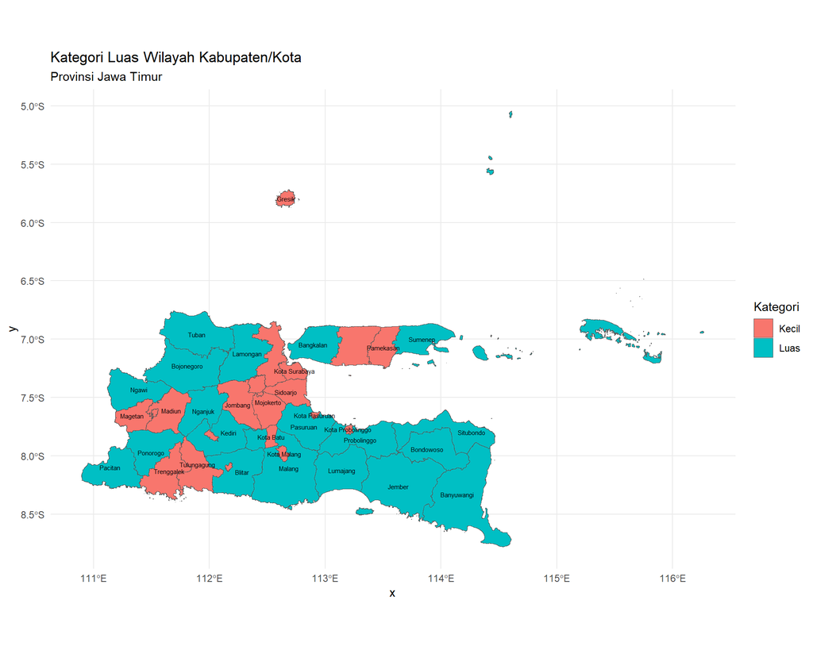

```r
library(ggplot2)

ggplot(jatim_lab) +
  geom_sf(aes(fill = kelas_luas)) +
  geom_sf_text(aes(label = kab_kota), size = 2, check_overlap = TRUE) +
  labs(
    title = "Kategori Luas Wilayah Kabupaten/Kota",
    subtitle = "Provinsi Jawa Timur",
    fill = "Kategori"
  ) +
  theme_minimal()
```

Modifikasi: `geom_sf_text()` ditambahkan untuk menampilkan nama kabupaten/kota langsung di peta.

## Kesimpulan

Dasar pemrograman R (variabel, operator, struktur data) dapat langsung diaplikasikan pada objek spasial `sf`. Data batas administrasi nyata memberikan konteks yang lebih relevan untuk analisis spasial wilayah Indonesia. Semua konsep dasar dari kode dosen tetap dipertahankan, hanya konteksnya yang disesuaikan dengan data Jawa Timur.